# HW2_Sabrina_Zhang

Author

Sabrina_Zhang

```r
library(nycflights13)
library(dplyr)
library(ggplot2)
library(leaflet)
library(tidyr)
library(cowplot)
```

## Q1. Top 10 Destinations

```r
tab_dest <- table(flights$dest)
tab_dest <- tab_dest[order(tab_dest, decreasing = TRUE)]
head(tab_dest, 10)
```

```
  ORD   ATL   LAX   BOS   MCO   CLT   SFO   FLL   MIA   DCA
17283 17215 16174 15508 14082 14064 13331 12055 11728  9705
```

The ten most popular destinations from New York City airports in 2013 were ORD (Chicago O’Hare) with 17,283 flights, ATL (Atlanta) with 17,215 flights, LAX (Los Angeles) with 16,174 flights, BOS (Boston) with 15,508 flights, MCO (Orlando) with 14,082 flights, CLT (Charlotte) with 14,064 flights, SFO (San Francisco) with 13,331 flights, FLL (Fort Lauderdale) with 12,055 flights, MIA (Miami) with 11,728 flights, and DCA (Washington National) with 9,705 flights.

## Q2. Departure and Arrival Time Categories and Red-Eye Flights

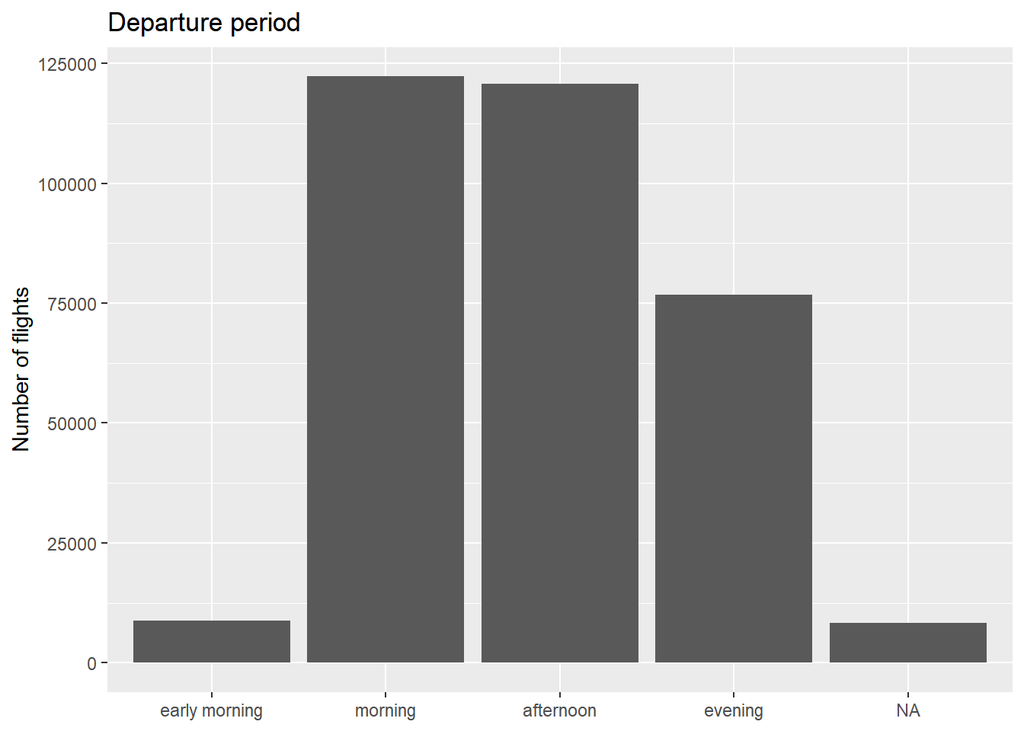

```r
# Convert departure and arrival times into hour of day
fl <- flights |>
  mutate(
    dep_hr = ifelse(dep_time == 2400, 0, dep_time %/% 100),
    arr_hr = ifelse(arr_time == 2400, 0, arr_time %/% 100),
    # cut() bins hours into four periods; right = FALSE gives [0,6), [6,12), [12,18), [18,24)
    dep_cat = cut(dep_hr, breaks = c(0, 6, 12, 18, 24),
                  labels = c("early morning", "morning", "afternoon", "evening"),
                  right = FALSE),
    arr_cat = cut(arr_hr, breaks = c(0, 6, 12, 18, 24),
                  labels = c("early morning", "morning", "afternoon", "evening"),
                  right = FALSE)
  )

# Bar plot of departure periods
ggplot(fl) + geom_bar(mapping = aes(x = dep_cat)) +
  labs(title = "Departure period", x = NULL, y = "Number of flights")
```

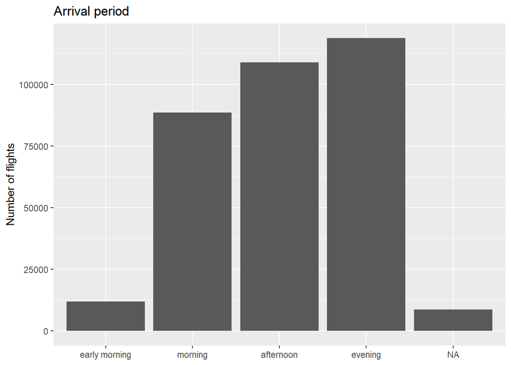

```r
# Bar plot of arrival periods
ggplot(fl) + geom_bar(mapping = aes(x = arr_cat)) +
  labs(title = "Arrival period", x = NULL, y = "Number of flights")
```

```r
# Red-eye flag: departs in afternoon/evening and arrives in early morning/morning
# NA if either time category is missing; and combine the conditions
is_red <- ifelse(
  is.na(fl$dep_cat) | is.na(fl$arr_cat),
  NA,
  (fl$dep_cat == "afternoon" | fl$dep_cat == "evening") &
    (fl$arr_cat == "early morning" | fl$arr_cat == "morning")
)

# Summary table of red-eye counts and percentage
red_table <- tibble(
  total_flights   = nrow(fl),
  red_is_na       = sum(is.na(is_red)),
  red_not_na      = sum(!is.na(is_red)),
  red_eye_flights = sum(is_red, na.rm = TRUE),
  red_eye_pct     = round(sum(is_red, na.rm = TRUE) /
                          sum(!is.na(is_red)) * 100, 2)
)

red_table
```

```
# A tibble: 1 × 5
  total_flights red_is_na red_not_na red_eye_flights red_eye_pct
          <int>     <int>      <int>           <int>       <dbl>
1        336776      8713     328063           10754        3.28
```

Based on visual inspection of the bar plots, departure times cluster in the morning and afternoon, with about just under 125,000 flights in each period. The evening has fewer, around 75,000, and very few flights leave in the early morning. Arrival times peak in the evening, followed by the afternoon and then the morning, with very few arriving in the early morning.

Of the 336,776 flights, 8,713 have a missing departure or arrival time, so they cannot be classified. Among the remaining 328,063 flights, 10,754 are red-eye flights, which is 3.28% of classified flights.

## Q3. Planes Flying for Multiple Airlines

```r
# Keep only flights that have a tail number, then keep unique tailnum-carrier pairs
pairs <- flights |>
  filter(!is.na(tailnum)) |>
  select(tailnum, carrier) |>
  unique()

# Count how many different carriers flew each plane, keep planes with more than one
multi <- pairs |>
  summarize(n_car = length(carrier), .by = tailnum) |>
  filter(n_car > 1)

# Number of planes that flew for more than one airline
nrow(multi)
```

```
[1] 17
```

```r
# Attach the full airline names from the airlines table
detail <- merge(x = multi, y = pairs, by = "tailnum")
detail <- merge(x = detail, y = airlines, by = "carrier")

# Keep one row per plane-carrier-name combination
pairs2 <- unique(detail[, c("tailnum", "carrier", "name")])

# One row per plane: number of airlines, codes and names joined with semicolons
mult_plane <- pairs2 |>
  group_by(tailnum) |>
  summarise(
    n_airlines    = length(carrier),
    carriers      = paste(carrier, collapse = ";"),
    airline_names = paste(name, collapse = ";")
  ) |>
  arrange(-n_airlines)

print(mult_plane)
```

```
# A tibble: 17 × 4
   tailnum n_airlines carriers airline_names
   <chr>        <int> <chr>    <chr>
 1 N146PQ           2 9E;EV    Endeavor Air Inc.;ExpressJet Airlines Inc.
 2 N153PQ           2 9E;EV    Endeavor Air Inc.;ExpressJet Airlines Inc.
 3 N176PQ           2 9E;EV    Endeavor Air Inc.;ExpressJet Airlines Inc.
 4 N181PQ           2 9E;EV    Endeavor Air Inc.;ExpressJet Airlines Inc.
 5 N197PQ           2 9E;EV    Endeavor Air Inc.;ExpressJet Airlines Inc.
 6 N200PQ           2 9E;EV    Endeavor Air Inc.;ExpressJet Airlines Inc.
 7 N228PQ           2 9E;EV    Endeavor Air Inc.;ExpressJet Airlines Inc.
 8 N232PQ           2 9E;EV    Endeavor Air Inc.;ExpressJet Airlines Inc.
 9 N933AT           2 DL;FL    Delta Air Lines Inc.;AirTran Airways Corporation
10 N935AT           2 DL;FL    Delta Air Lines Inc.;AirTran Airways Corporation
11 N977AT           2 DL;FL    Delta Air Lines Inc.;AirTran Airways Corporation
12 N978AT           2 DL;FL    Delta Air Lines Inc.;AirTran Airways Corporation
13 N979AT           2 DL;FL    Delta Air Lines Inc.;AirTran Airways Corporation
14 N981AT           2 DL;FL    Delta Air Lines Inc.;AirTran Airways Corporation
15 N989AT           2 DL;FL    Delta Air Lines Inc.;AirTran Airways Corporation
16 N990AT           2 DL;FL    Delta Air Lines Inc.;AirTran Airways Corporation
17 N994AT           2 DL;FL    Delta Air Lines Inc.;AirTran Airways Corporation
```

Yes, 17 planes flew for more than one airline. Each of them flew for exactly two airlines, falling into two groups as follows.

8 planes (tail numbers N146PQ, N153PQ, N176PQ, N181PQ, N197PQ, N200PQ, N228PQ, N232PQ) flew for Endeavor Air Inc. (carrier code 9E) and ExpressJet Airlines Inc. (carrier code EV).

9 planes (tail numbers N933AT, N935AT, N977AT, N978AT, N979AT, N981AT, N989AT, N990AT, N994AT) flew for Delta Air Lines Inc. (carrier code DL) and AirTran Airways Corporation (carrier code FL).

## Q4. Missing Relationship in the Diagram (7 pts): Identify the relationship between the weather and airports tables that is missing from the diagram, and explain how it should be drawn.

```r
unique(weather$origin)
```

```
[1] "EWR" "JFK" "LGA"
```

```r
head(airports[, c("faa", "name")])
```

```
# A tibble: 6 × 2
  faa   name
  <chr> <chr>
1 04G   Lansdowne Airport
2 06A   Moton Field Municipal Airport
3 06C   Schaumburg Regional
4 06N   Randall Airport
5 09J   Jekyll Island Airport
6 0A9   Elizabethton Municipal Airport
```

The diagram is missing a relationship between the weather and airports tables. The airports table contains a variable, faa, that directly matches the origin variable in the weather table. Both use the standard three-letter airport codes assigned by the Federal Aviation Administration (FAA), so the origin variable in weather can be used to look up the information about that airport in airports. This relationship should be drawn as a line connecting weather column origin to airports column faa. It is a many-to-one relationship: each airport has many hourly weather records in weather, but each airport code appears only once in airports. The weather table only covers the three New York City airports (EWR, JFK, and LGA) during 2013, because the nycflights13 package was built around flights leaving those airports that year. This is why the line connects only to origin and not to dest.

## Q5. Building a Unique Key and Merging Weather with Flights

```r
# Build a key from year, month, day, hour and origin in both tables
weather$key <- paste0(weather$year, "-", weather$month, "-", weather$day,
                      "-", weather$hour, "-", weather$origin)

# Count duplicated keys, and compare with duplicates based on time_hour and origin
sum(duplicated(weather$key))
```

```
[1] 3
```

```r
sum(duplicated(paste0(weather$time_hour, "-", weather$origin)))
```

```
[1] 3
```

```r
# Show all weather rows whose key appears more than once
dup_keys <- weather$key[duplicated(weather$key)]
weather[weather$key %in% dup_keys, ]
```

```
# A tibble: 6 × 16
  origin  year month   day  hour  temp  dewp humid wind_dir wind_speed wind_gust
  <chr>  <int> <int> <int> <int> <dbl> <dbl> <dbl>    <dbl>      <dbl>     <dbl>
1 EWR     2013    11     3     1  52.0  39.0  61.2      310       6.90        NA
2 EWR     2013    11     3     1  50    39.0  65.8      290       5.75        NA
3 JFK     2013    11     3     1  54.0  37.9  54.5      320       9.21        NA
4 JFK     2013    11     3     1  52.0  37.9  58.6      310       6.90        NA
5 LGA     2013    11     3     1  55.0  39.0  54.7      330       9.21        NA
6 LGA     2013    11     3     1  54.0  39.9  58.9      310       8.06        NA
# ℹ 5 more variables: precip <dbl>, pressure <dbl>, visib <dbl>,
#   time_hour <dttm>, key <chr>
```

```r
# Check whether any flights departed in the repeated 1 AM hour on 3 November
flights[flights$month == 11 & flights$day == 3 & flights$hour == 1, ]
```

```
# A tibble: 0 × 19
# ℹ 19 variables: year <int>, month <int>, day <int>, dep_time <int>,
#   sched_dep_time <int>, dep_delay <dbl>, arr_time <int>,
#   sched_arr_time <int>, arr_delay <dbl>, carrier <chr>, flight <int>,
#   tailnum <chr>, origin <chr>, dest <chr>, air_time <dbl>, distance <dbl>,
#   hour <dbl>, minute <dbl>, time_hour <dttm>
```

```r
# Keep only the weather columns needed for the merge
w <- weather[, c("origin", "time_hour", "temp", "dewp", "humid", "wind_dir",
                 "wind_speed", "wind_gust", "precip", "pressure", "visib")]

# Merge weather into flights by time_hour and origin, keeping every flight (all.x = TRUE)
m <- merge(x = flights, y = w, by = c("time_hour", "origin"), all.x = TRUE)

# Check that the merged table has the same number of rows as flights
nrow(m) == nrow(flights)
```

```
[1] TRUE
```

We built a key for each weather record by pasting together its year, month, day, hour, and origin.

Checking the weather table, we found three duplicated keys. Inspecting these records showed that all of them fall on 3 November 2013, the day daylight saving time ended, during the 1:00 AM hour that occurred twice. The time_hour variable gives the same value for these repeated records, so comparing time_hour and origin also finds three duplicates. The key therefore adds no information beyond time_hour and origin. The flights table contains no flights scheduled in that hour, so these duplicates cannot match any flight and will not create extra rows when the tables are merged.

We then merged the weather variables into flights using time_hour and origin with all.x = TRUE, which keeps every flight record. We confirmed that the merged dataset has the same number of rows as the original flights table.

## Q6. EDA on the Merged Dataset

```r
# Step 2: check the size of the merged data
dim(m)
```

```
[1] 336776     28
```

```r
nrow(m)
```

```
[1] 336776
```

```r
# Step 3: check variable names, types, and summaries of key variables
str(m)
```

```
'data.frame':   336776 obs. of  28 variables:
 $ time_hour     : POSIXct, format: "2013-01-01 05:00:00" "2013-01-01 05:00:00" ...
 $ origin        : chr  "EWR" "EWR" "JFK" "JFK" ...
 $ year          : int  2013 2013 2013 2013 2013 2013 2013 2013 2013 2013 ...
 $ month         : int  1 1 1 1 1 1 1 1 1 1 ...
 $ day           : int  1 1 1 1 1 1 1 1 1 1 ...
 $ dep_time      : int  517 554 559 542 544 533 732 629 624 643 ...
 $ sched_dep_time: int  515 558 559 540 545 529 645 630 630 646 ...
 $ dep_delay     : num  2 -4 0 2 -1 4 47 -1 -6 -3 ...
 $ arr_time      : int  830 740 702 923 1004 850 1011 824 909 922 ...
 $ sched_arr_time: int  819 728 706 850 1022 830 941 833 840 940 ...
 $ arr_delay     : num  11 12 -4 33 -18 20 30 -9 29 -18 ...
 $ carrier       : chr  "UA" "UA" "B6" "AA" ...
 $ flight        : int  1545 1696 1806 1141 725 1714 1111 1019 4626 556 ...
 $ tailnum       : chr  "N14228" "N39463" "N708JB" "N619AA" ...
 $ dest          : chr  "IAH" "ORD" "BOS" "MIA" ...
 $ air_time      : num  227 150 44 160 183 227 145 91 190 146 ...
 $ distance      : num  1400 719 187 1089 1576 ...
 $ hour          : num  5 5 5 5 5 5 6 6 6 6 ...
 $ minute        : num  15 58 59 40 45 29 45 30 30 46 ...
 $ temp          : num  39 39 39 39 39 ...
 $ dewp          : num  28 28 27 27 27 ...
 $ humid         : num  64.4 64.4 61.6 61.6 61.6 ...
 $ wind_dir      : num  260 260 260 260 260 250 240 240 240 240 ...
 $ wind_speed    : num  12.7 12.7 15 15 15 ...
 $ wind_gust     : num  NA NA NA NA NA ...
 $ precip        : num  0 0 0 0 0 0 0 0 0 0 ...
 $ pressure      : num  1012 1012 1012 1012 1012 ...
 $ visib         : num  10 10 10 10 10 10 10 10 10 10 ...
```

```r
summary(m[, c("dep_delay", "arr_delay", "precip", "visib", "wind_speed", "temp", "pressure", "wind_gust")])
```

```
   dep_delay         arr_delay            precip             visib
 Min.   : -43.00   Min.   : -86.000   Min.   :0.000000   Min.   : 0.000
 1st Qu.:  -5.00   1st Qu.: -17.000   1st Qu.:0.000000   1st Qu.:10.000
 Median :  -2.00   Median :  -5.000   Median :0.000000   Median :10.000
 Mean   :  12.64   Mean   :   6.895   Mean   :0.004564   Mean   : 9.256
 3rd Qu.:  11.00   3rd Qu.:  14.000   3rd Qu.:0.000000   3rd Qu.:10.000
 Max.   :1301.00   Max.   :1272.000   Max.   :1.210000   Max.   :10.000
 NAs    :8255      NAs    :9430       NAs    :1556       NAs    :1556
   wind_speed          temp           pressure        wind_gust
 Min.   : 0.000   Min.   : 10.94   Min.   : 983.8   Min.   :16.11
 1st Qu.: 6.905   1st Qu.: 42.08   1st Qu.:1012.7   1st Qu.:20.71
 Median :10.357   Median : 57.20   Median :1017.5   Median :24.17
 Mean   :11.114   Mean   : 57.00   Mean   :1017.8   Mean   :25.25
 3rd Qu.:14.960   3rd Qu.: 71.96   3rd Qu.:1022.8   3rd Qu.:28.77
 Max.   :42.579   Max.   :100.04   Max.   :1042.1   Max.   :66.75
 NAs    :1634     NAs    :1573     NAs    :38788    NAs    :256391
```

```r
# Step 4: look at the top and bottom of the data
head(m)
```

```
            time_hour origin year month day dep_time sched_dep_time dep_delay
1 2013-01-01 05:00:00    EWR 2013     1   1      517            515         2
2 2013-01-01 05:00:00    EWR 2013     1   1      554            558        -4
3 2013-01-01 05:00:00    JFK 2013     1   1      559            559         0
4 2013-01-01 05:00:00    JFK 2013     1   1      542            540         2
5 2013-01-01 05:00:00    JFK 2013     1   1      544            545        -1
6 2013-01-01 05:00:00    LGA 2013     1   1      533            529         4
  arr_time sched_arr_time arr_delay carrier flight tailnum dest air_time
1      830            819        11      UA   1545  N14228  IAH      227
2      740            728        12      UA   1696  N39463  ORD      150
3      702            706        -4      B6   1806  N708JB  BOS       44
4      923            850        33      AA   1141  N619AA  MIA      160
5     1004           1022       -18      B6    725  N804JB  BQN      183
6      850            830        20      UA   1714  N24211  IAH      227
  distance hour minute  temp  dewp humid wind_dir wind_speed wind_gust precip
1     1400    5     15 39.02 28.04 64.43      260   12.65858        NA      0
2      719    5     58 39.02 28.04 64.43      260   12.65858        NA      0
3      187    5     59 39.02 26.96 61.63      260   14.96014        NA      0
4     1089    5     40 39.02 26.96 61.63      260   14.96014        NA      0
5     1576    5     45 39.02 26.96 61.63      260   14.96014        NA      0
6     1416    5     29 39.92 24.98 54.81      250   14.96014  21.86482      0
  pressure visib
1   1011.9    10
2   1011.9    10
3   1012.1    10
4   1012.1    10
5   1012.1    10
6   1011.4    10
```

```r
tail(m)
```

```
                 time_hour origin year month day dep_time sched_dep_time
336771 2013-12-31 22:00:00    JFK 2013    12  31     2218           2219
336772 2013-12-31 23:00:00    EWR 2013    12  31     2328           2330
336773 2013-12-31 23:00:00    JFK 2013    12  31     2355           2359
336774 2013-12-31 23:00:00    JFK 2013    12  31     2356           2359
336775 2013-12-31 23:00:00    JFK 2013    12  31       13           2359
336776 2013-12-31 23:00:00    JFK 2013    12  31       18           2359
       dep_delay arr_time sched_arr_time arr_delay carrier flight tailnum dest
336771        -1      315            304        11      B6   1203  N625JB  SJU
336772        -2      412            409         3      B6   1389  N651JB  SJU
336773        -4      430            440       -10      B6   1503  N509JB  SJU
336774        -3      436            445        -9      B6    745  N665JB  PSE
336775        14      439            437         2      B6    839  N566JB  BQN
336776        19      449            444         5      DL    412  N713TW  SJU
       air_time distance hour minute temp dewp humid wind_dir wind_speed
336771      202     1598   22     19   NA   NA    NA       NA         NA
336772      198     1608   23     30   NA   NA    NA       NA         NA
336773      195     1598   23     59   NA   NA    NA       NA         NA
336774      200     1617   23     59   NA   NA    NA       NA         NA
336775      189     1576   23     59   NA   NA    NA       NA         NA
336776      192     1598   23     59   NA   NA    NA       NA         NA
       wind_gust precip pressure visib
336771        NA     NA       NA    NA
336772        NA     NA       NA    NA
336773        NA     NA       NA    NA
336774        NA     NA       NA    NA
336775        NA     NA       NA    NA
336776        NA     NA       NA    NA
```

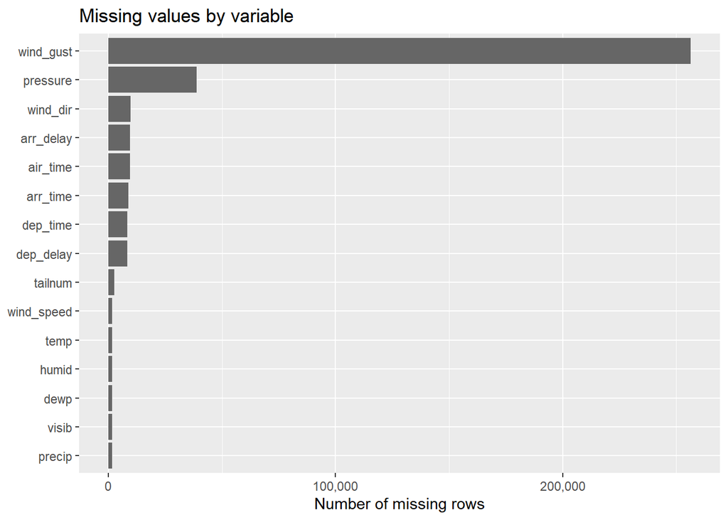

```r
# Step 5: visualize distributions and data quality

# 5a. Missing values per variable
na_tab <- data.frame(variable = names(m), n_missing = colSums(is.na(m))) |>
  filter(n_missing > 0) |>
  arrange(desc(n_missing))

library(scales)

ggplot(na_tab, aes(x = reorder(variable, n_missing), y = n_missing)) +
  geom_col(fill = "grey40") +
  coord_flip() +
  scale_y_continuous(labels = label_comma()) +
  labs(title = "Missing values by variable",
       x = NULL, y = "Number of missing rows")
```

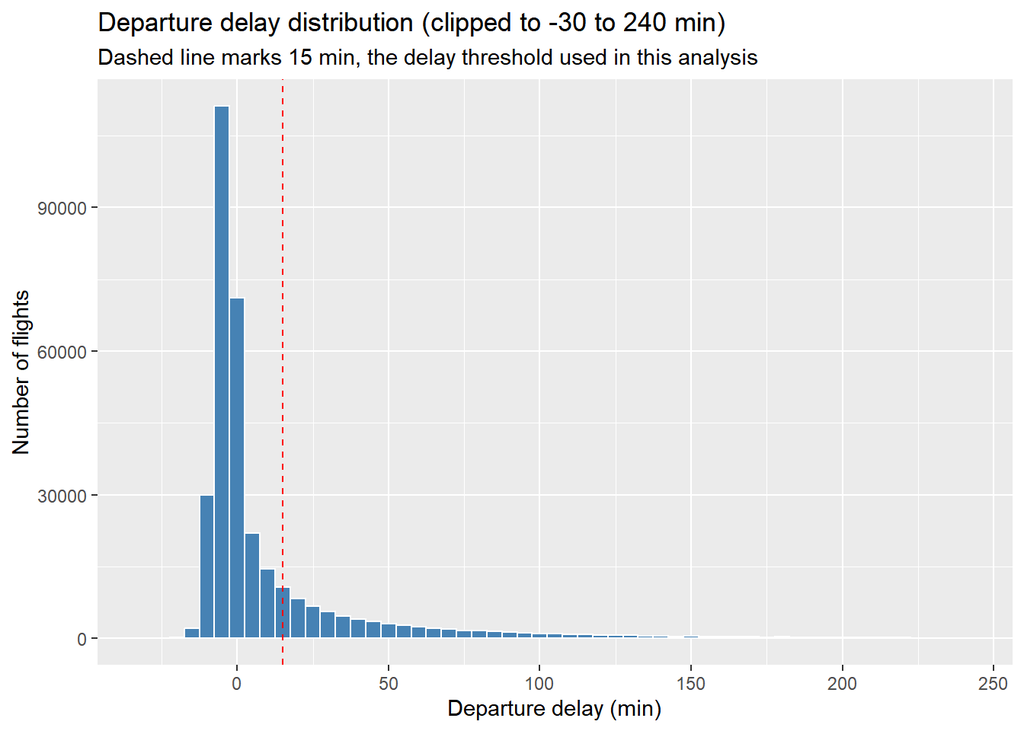

```r
# 5b. Departure delay distribution, clipped to -30 to 240 min for readability
ggplot(filter(m, !is.na(dep_delay), dep_delay >= -30, dep_delay <= 240),
       aes(x = dep_delay)) +
  geom_histogram(binwidth = 5, fill = "steelblue", color = "white") +
  geom_vline(xintercept = 15, linetype = "dashed", color = "red") +
  labs(title = "Departure delay distribution (clipped to -30 to 240 min)",
       subtitle = "Dashed line marks 15 min, the delay threshold used in this analysis",
       x = "Departure delay (min)", y = "Number of flights")
```

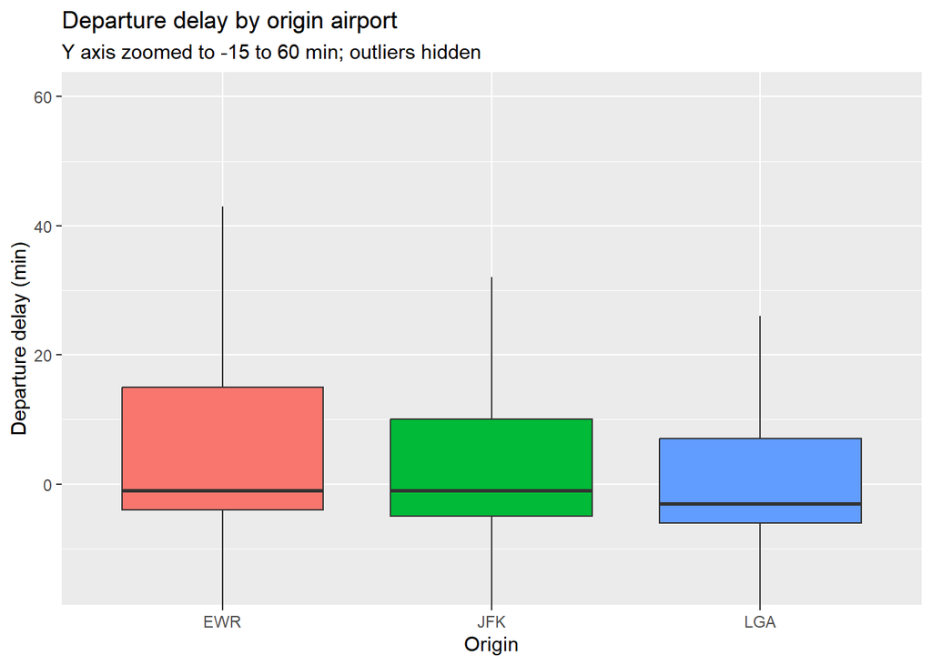

```r
# 5c. Departure delay by origin airport, zoomed to the box range
ggplot(filter(m, !is.na(dep_delay)),
       aes(x = origin, y = dep_delay, fill = origin)) +
  geom_boxplot(outlier.shape = NA, show.legend = FALSE) +
  coord_cartesian(ylim = c(-15, 60)) +
  labs(title = "Departure delay by origin airport",
       subtitle = "Y axis zoomed to -15 to 60 min; outliers hidden",
       x = "Origin", y = "Departure delay (min)")
```

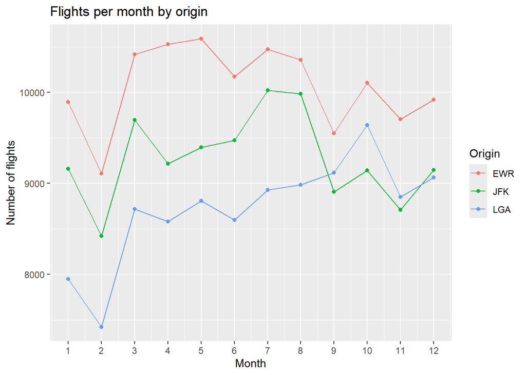

```r
# 5d. Flights per month and origin, to check time coverage
m |>
  count(origin, month) |>
  ggplot(aes(x = month, y = n, color = origin)) +
  geom_line() +
  geom_point() +
  scale_x_continuous(breaks = 1:12) +
  labs(title = "Flights per month by origin",
       x = "Month", y = "Number of flights", color = "Origin")
```

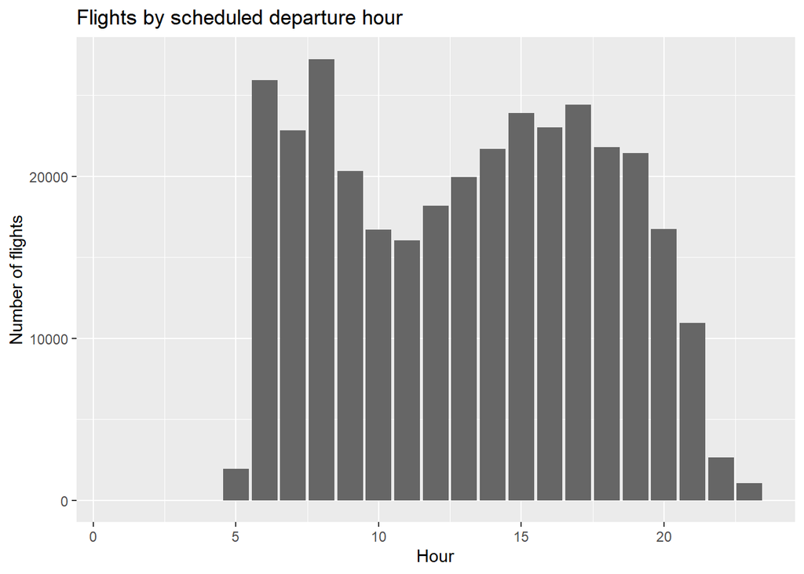

```r
# 5e. Flights by hour of the scheduled departure
m |>
  count(hour) |>
  ggplot(aes(x = hour, y = n)) +
  geom_col(fill = "grey40") +
  labs(title = "Flights by scheduled departure hour",
       x = "Hour", y = "Number of flights")
```

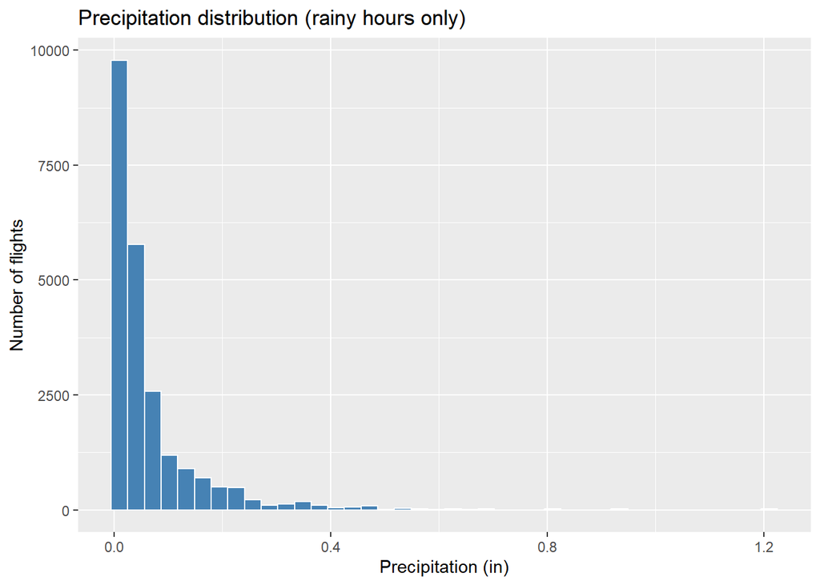

```r
# 5f. Distribution of precipitation, rainy hours only
ggplot(filter(m, !is.na(precip), precip > 0), aes(x = precip)) +
  geom_histogram(bins = 40, fill = "steelblue", color = "white") +
  labs(title = "Precipitation distribution (rainy hours only)",
       x = "Precipitation (in)", y = "Number of flights")
```

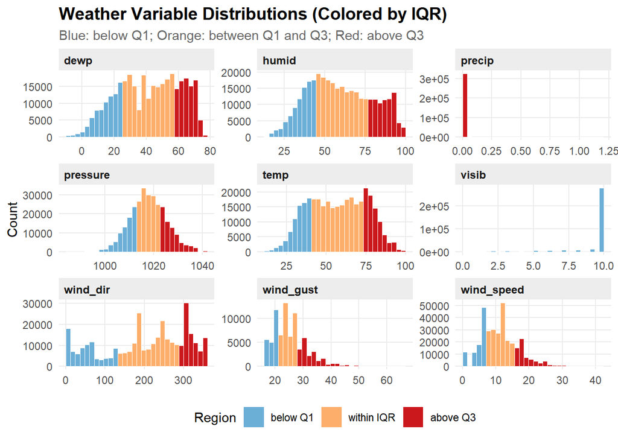

```r
# 5g. Weather variable distributions, colored by IQR
weather_vars <- c("temp", "dewp", "humid", "wind_dir", "wind_speed",
                  "wind_gust", "precip", "pressure", "visib")

# Reshape to long format: one row per variable-value pair
long <- m[, weather_vars] |>
  pivot_longer(everything(),
               names_to = "variable",
               values_to = "value") |>
  filter(!is.na(value))

# Q1, Q3 and IQR for each weather variable
iqr_tab <- long |>
  summarize(
    q1  = quantile(value, 0.25),
    q3  = quantile(value, 0.75),
    iqr = q3 - q1,
    .by = variable
  )

# Build 30 equal-width bins per variable and tag each bin by its midpoint
make_hist <- function(v) {
  x   <- long$value[long$variable == v]
  q   <- iqr_tab[iqr_tab$variable == v, ]
  brk <- seq(min(x), max(x), length.out = 31)
  idx <- findInterval(x, brk, rightmost.closed = TRUE, all.inside = TRUE)
  cnt <- tabulate(idx, nbins = 30)
  mid <- (brk[-31] + brk[-1]) / 2
  data.frame(
    variable = v,
    xmin  = brk[-31],
    xmax  = brk[-1],
    count = cnt,
    region = ifelse(mid < q$q1, "below Q1",
             ifelse(mid > q$q3, "above Q3", "within IQR"))
  )
}

hist_df <- bind_rows(lapply(weather_vars, make_hist))

my_theme <- theme_minimal(base_size = 11) +
  theme(
    plot.title       = element_text(face = "bold", size = 14),
    plot.subtitle    = element_text(color = "grey40"),
    strip.text       = element_text(face = "bold", size = 9, hjust = 0),
    strip.background = element_rect(fill = "grey93", color = NA),
    panel.grid.minor = element_blank(),
    legend.position  = "bottom"
  )

ggplot(hist_df) +
  geom_rect(aes(xmin = xmin, xmax = xmax, ymin = 0, ymax = count, fill = region),
            color = "white", linewidth = 0.2) +
  facet_wrap(~ variable, scales = "free") +
  scale_fill_manual(values = c("below Q1"   = "#6BAED6",
                               "within IQR" = "#FDAE6B",
                               "above Q3"   = "#CB181D"),
                    breaks = c("below Q1", "within IQR", "above Q3")) +
  labs(title = "Weather Variable Distributions (Colored by IQR)",
       subtitle = "Blue: below Q1; Orange: between Q1 and Q3; Red: above Q3",
       x = NULL, y = "Count", fill = "Region") +
  my_theme
```

Exploratory Data Analysis. We began by checking the merged dataset m. It has 336,776 flight records and 28 variables, which matches the row count of the original flights table, so the weather merge did not add or drop flights. The variables include the flight identifiers, scheduled and actual times, delays, and the weather measurements joined by the origin and time_hour.

Several key variables have missing values. arr_delay has 9,430 missing values and dep_delay has 8,255. These are likely cancelled or diverted flights that never departed or arrived, which is why they have no delay record. Among the weather variables, wind_gust has the most missing values, followed by pressure. wind_speed (1,634), temp (1,573), precip (1,556), and visib (1,556) have far fewer missing values. Because wind_gust is missing so often, any result that uses it rests on a smaller sample than the other weather variables.

The departure delay is strongly right-skewed. The median is -2 minutes and the mean is 12.64 minutes, so most flights leave on time or only slightly late, and a small number of flights have very long delays (the maximum is 1,301 minutes).

The boxplots show that the three airports have similar median departure delays, with LGA slightly lower. EWR has a higher third quartile and a longer upper whisker, which means its severe delays are more common than at JFK or LGA.

The monthly flight counts show that EWR has the most flights in every month of the year, followed by JFK and then LGA. From September to November, LGA’s flight count rises above JFK’s.

Most flights are scheduled to depart between 5 AM and 9 PM, so flights outside that window are rare and contribute little to the overall picture.

For the weather variables, most distributions are roughly bell-shaped or at least not extreme, but precipitation is strongly right-skewed. Heavy rain is very rare, and most hours have no precipitation at all. Visibility is strongly left-skewed: its median and upper quartile are both 10 miles, so most observations are at the maximum, and only a few hours have reduced visibility. The IQR-colored histograms show this directly.

## Q7. Average Departure Delays

```r
# Average departure delay for each day
daily <- m |>
  summarize(avg_dep = mean(dep_delay, na.rm = TRUE), .by = c(year, month, day))

# Day with the highest average departure delay
daily[order(daily$avg_dep, decreasing = TRUE), ][1, ]
```

```
   year month day  avg_dep
67 2013     3   8 83.53692
```

```r
# Average departure delay for each day and origin airport
day_orig <- m |>
  summarize(avg_dep = mean(dep_delay, na.rm = TRUE), .by = c(origin, year, month, day))

# Top 5 airport-days with the highest average departure delay
day_orig[order(day_orig$avg_dep, decreasing = TRUE), ][1:5, ]
```

```
     origin year month day   avg_dep
201     LGA 2013     3   8 105.72489
199     EWR 2013     3   8  97.77068
735     LGA 2013     9   2  80.49187
1017    LGA 2013    12   5  75.25000
572     JFK 2013     7  10  63.63279
```

```r
# Average departure delay for each hour and origin airport
hr_orig <- m |>
  summarize(avg_dep = mean(dep_delay, na.rm = TRUE), .by = c(origin, year, month, day, hour))

# Top 5 airport-hours with the highest average departure delay
hr_orig[order(hr_orig$avg_dep, decreasing = TRUE), ][1:5, ]
```

```
      origin year month day hour  avg_dep
11161    LGA 2013     7  28   21 279.6667
2080     EWR 2013     2   9   10 269.0000
2077     EWR 2013     2   9    9 266.0000
13075    LGA 2013     9   2   16 250.3077
10829    LGA 2013     7  22   18 246.4000
```

The day with the worst average departure delay was March 8, 2013, at 83.5 minutes. Grouped by day and origin, the worst single day was LGA on March 8, 2013, at 105.7 minutes. Grouped by hour and origin, the worst single hour was LGA on July 28, 2013, at 9 PM, with an average departure delay of 279.7 minutes.

## Q8. Map of Average Arrival Delay by Destination

```r
arr_dest <- m |>
  summarize(avg_arr = mean(arr_delay, na.rm = TRUE), .by = dest)

ap <- merge(x = airports, y = arr_dest, by.x = "faa", by.y = "dest")

pal <- colorNumeric(c("darkgreen", "goldenrod", "brown"), domain = ap$avg_arr)
leaflet(ap) |>
  addTiles() |>
  addCircles(lat = ~lat, lng = ~lon,
             color = ~pal(avg_arr),
             label = ~paste0(faa, ": ", round(avg_arr, 1), " min"),
             opacity = 1, fillOpacity = 1, radius = 500) |>
  addLegend("bottomleft", pal = pal, values = ap$avg_arr,
            title = "Average Arrival Delay (min)", opacity = 1)
```

[interactive chart not shown]

Based on visual inspection of the map, the airports with the highest average arrival delays are shown in red. Tulsa (TUL), Oklahoma City (OKC), and Columbia, South Carolina (CAE) are among the most delayed destinations, with CAE averaging about 41.8 minutes. Most airports on the West Coast are shown in green, meaning they have relatively low average arrival delays. Lexington (LEX) is the only airport with a negative average, about -22 minutes, meaning flights arrived earlier than scheduled on average.

## Q9. Main Question: Which Weather Phenomena Affect Flight Delays Most?

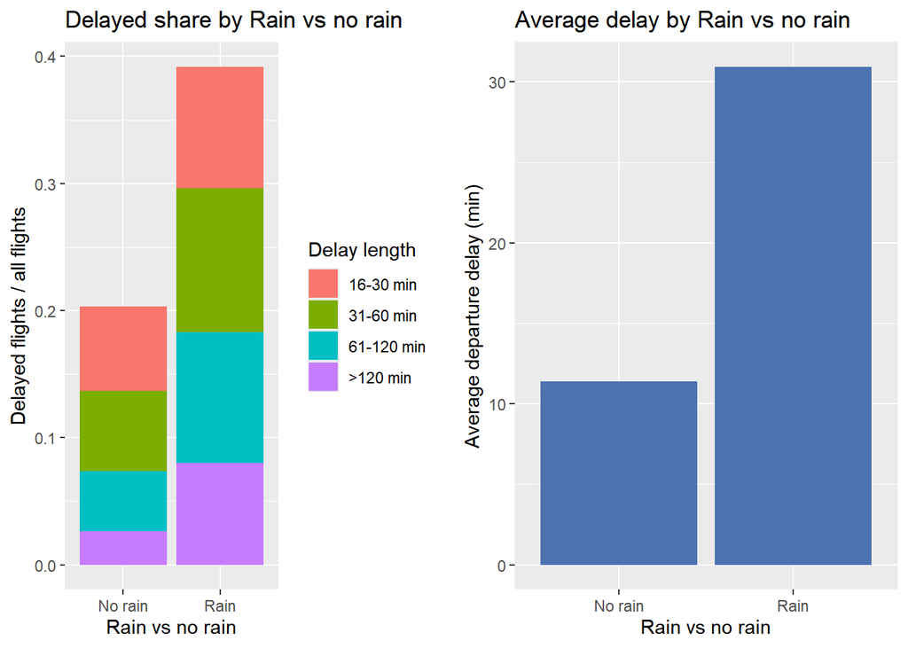

```r
#Q9.a For each weather variable, draw two plots side by side:
# left = delayed flights as a share of all flights (stacked by delay length),
# right = average departure delay by weather bin
plot_pair <- function(var, breaks, labels, title) {

  base <- m |>
    filter(!is.na(dep_delay), !is.na(.data[[var]])) |>
    mutate(
      wx  = cut(.data[[var]], breaks = breaks, labels = labels),
      sev = cut(dep_delay,
                breaks = c(15, 30, 60, 120, Inf),
                labels = c("16-30 min", "31-60 min", "61-120 min", ">120 min"))
    )   # Delay is defined as departure more than 15 min late, following FAA convention

  # Total number of flights in each weather bin (denominator)
  n_total <- base |>
    summarize(total = length(dep_delay), .by = wx)

  # Number of delayed flights in each weather bin and delay-length group
  seg <- base |>
    filter(!is.na(sev)) |>
    summarize(n = length(dep_delay), .by = c(wx, sev)) |>
    merge(n_total, by = "wx") |>
    mutate(ratio = n / total)

  p_ratio <- ggplot(seg, aes(x = wx, y = ratio, fill = sev)) +
    geom_col() +
    labs(title = paste("Delayed share by", title),
         x = title, y = "Delayed flights / all flights",
         fill = "Delay length")

  # Average departure delay within each weather bin
  avg_tab <- base |>
    summarize(avg_delay = mean(dep_delay), .by = wx)

  p_avg <- ggplot(avg_tab, aes(x = wx, y = avg_delay)) +
    geom_col(fill = "#4C72B0") +
    labs(title = paste("Average delay by", title),
         x = title, y = "Average departure delay (min)")

  plot_grid(p_ratio, p_avg, ncol = 2)
}

# Rain vs no rain (precip split at 0)
plot_pair("precip",
          breaks = c(-Inf, 0, Inf),
          labels = c("No rain", "Rain"),
          title = "Rain vs no rain")
```

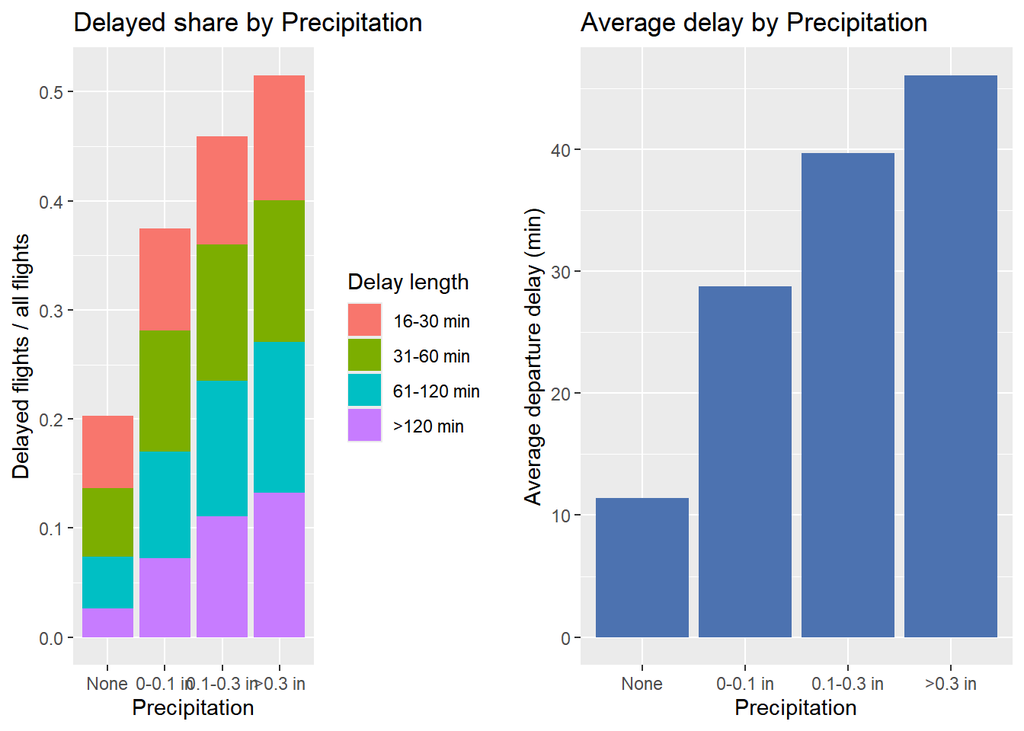

```r
# Rainfall amount
plot_pair("precip",
          breaks = c(-Inf, 0, 0.1, 0.3, Inf),
          labels = c("None", "0-0.1 in", "0.1-0.3 in", ">0.3 in"),
          title = "Precipitation")
```

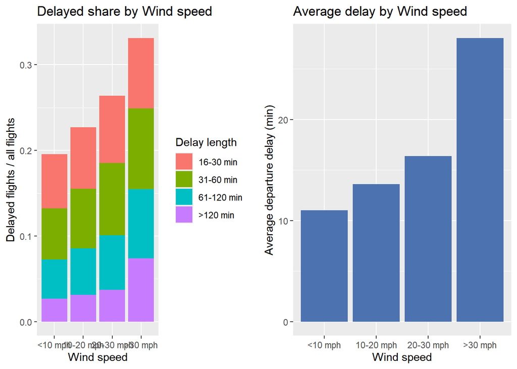

```r
plot_pair("wind_speed",
          breaks = c(-Inf, 10, 20, 30, Inf),
          labels = c("<10 mph", "10-20 mph", "20-30 mph", ">30 mph"),
          title = "Wind speed")
```

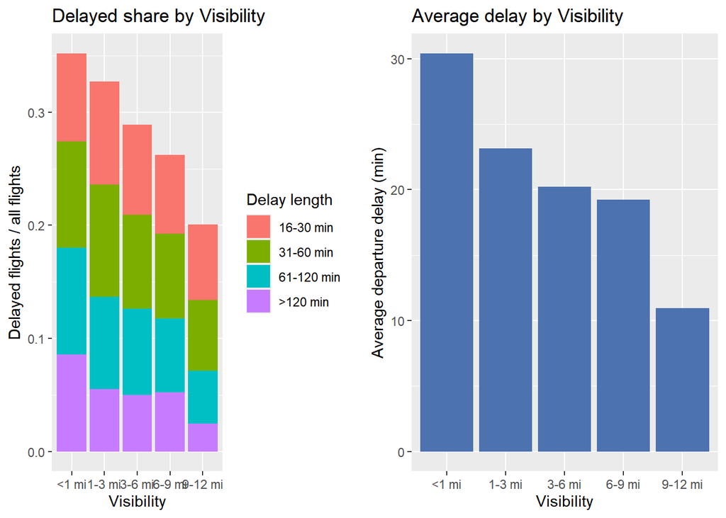

```r
plot_pair("visib",
          breaks = c(-Inf, 1, 3, 6, 9, 12),
          labels = c("<1 mi", "1-3 mi", "3-6 mi", "6-9 mi", "9-12 mi"),
          title = "Visibility")
```

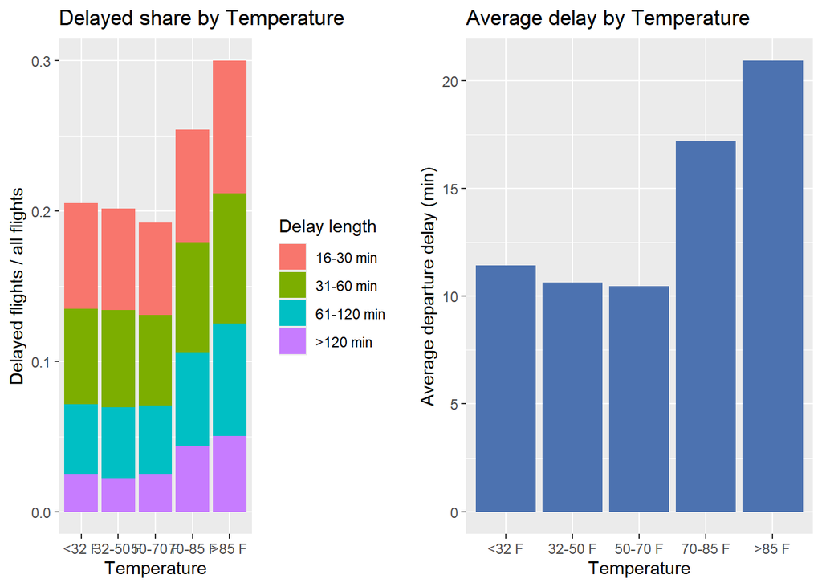

```r
plot_pair("temp",
          breaks = c(-Inf, 32, 50, 70, 85, Inf),
          labels = c("<32 F", "32-50 F", "50-70 F", "70-85 F", ">85 F"),
          title = "Temperature")
```

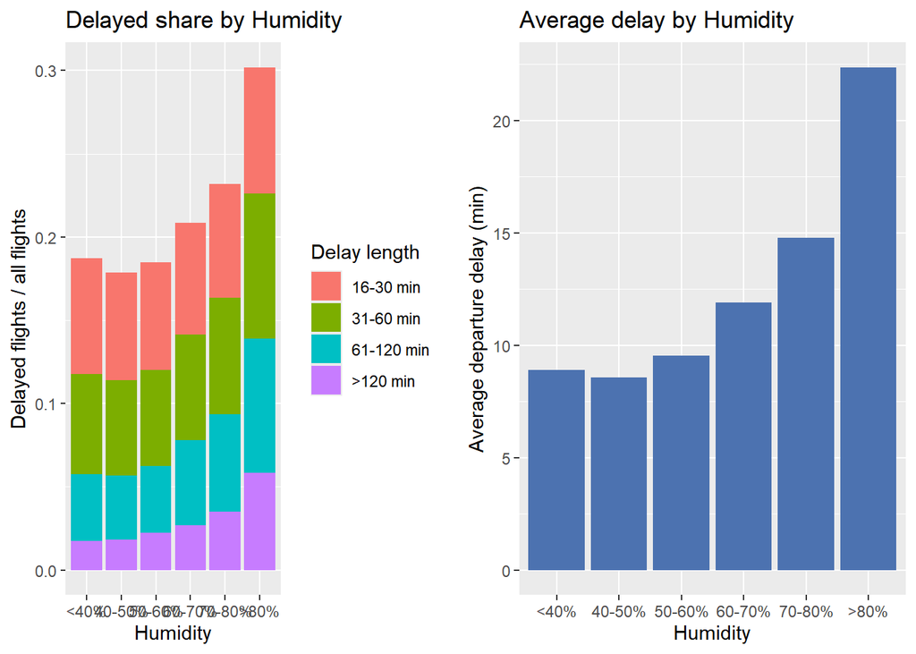

```r
plot_pair("humid",
          breaks = c(-Inf, 40, 50, 60, 70, 80, Inf),
          labels = c("<40%", "40-50%", "50-60%", "60-70%", "70-80%", ">80%"),
          title = "Humidity")
```

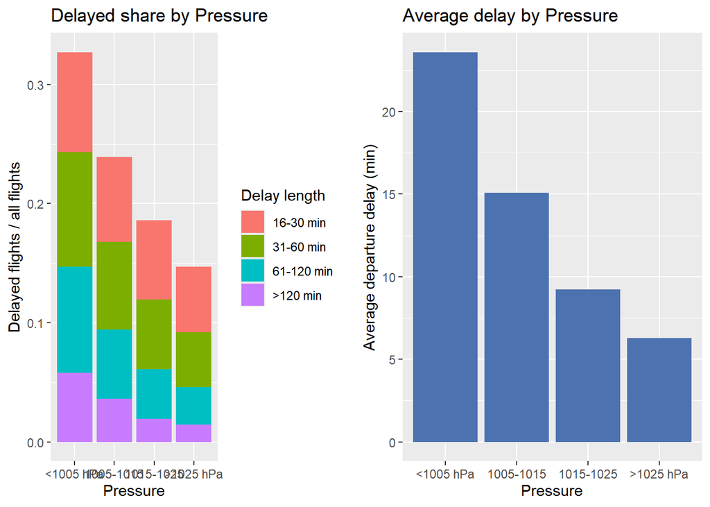

```r
plot_pair("pressure",
          breaks = c(-Inf, 1005, 1015, 1025, Inf),
          labels = c("<1005 hPa", "1005-1015", "1015-1025", ">1025 hPa"),
          title = "Pressure")
```

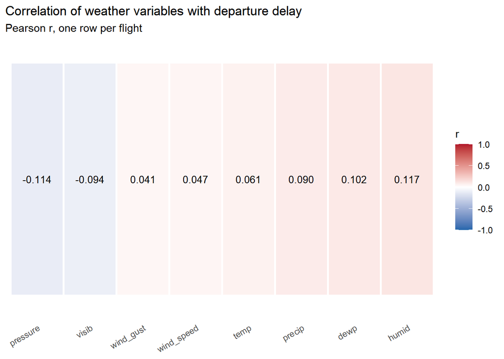

```r
# Q9.b Pearson correlation between each weather variable and departure delay,
#    using the merged table m (one row per flight)
weather_vars <- c("temp", "dewp", "humid", "wind_speed", "wind_gust",
                  "precip", "pressure", "visib")

cor_tab <- data.frame(
  variable = weather_vars,
  r = sapply(weather_vars, function(v)
    cor(m$dep_delay, m[[v]], use = "complete.obs"))
)

cor_tab <- cor_tab |>
  arrange(r) |>
  mutate(variable = factor(variable, levels = variable),
         y = "Departure delay")

# Heatmap: color shows sign and strength of r; cell labels show the value
ggplot(cor_tab, aes(x = variable, y = y, fill = r)) +
  geom_tile(color = "white", linewidth = 1) +
  geom_text(aes(label = sprintf("%.3f", r)), size = 3.5) +
  scale_fill_gradient2(low = "#2166AC", mid = "white", high = "#B2182B",
                       midpoint = 0, limits = c(-1, 1),
                       name = "r") +
  labs(title = "Correlation of weather variables with departure delay",
       subtitle = "Pearson r, one row per flight",
       x = NULL, y = NULL) +
  theme_minimal(base_size = 11) +
  theme(axis.text.y = element_blank(),
        axis.ticks = element_blank(),
        panel.grid = element_blank(),
        axis.text.x = element_text(angle = 30, hjust = 1))
```

```r
#Q9.c Build one summary block per weather variable, using the same bins as plot_pair
summ_one <- function(var, breaks, labels, title) {
  m |>
    filter(!is.na(dep_delay), !is.na(.data[[var]])) |>
    mutate(wx = cut(.data[[var]], breaks = breaks, labels = labels)) |>
    summarize(
      variable      = title,
      n_flights     = length(dep_delay),
      delay_rate_15 = mean(dep_delay > 15),
      share_60      = mean(dep_delay > 60),
      share_120     = mean(dep_delay > 120),
      .by = wx
    ) |>
    rename(category = wx)
}

summary_tab <- bind_rows(
  summ_one("precip", c(-Inf, 0, Inf), c("No rain", "Rain"), "Rain (yes/no)"),
  summ_one("precip", c(-Inf, 0, 0.1, 0.3, Inf),
           c("None", "0-0.1 in", "0.1-0.3 in", ">0.3 in"), "Precipitation"),
  summ_one("wind_speed", c(-Inf, 10, 20, 30, Inf),
           c("<10 mph", "10-20 mph", "20-30 mph", ">30 mph"), "Wind speed"),
  summ_one("visib", c(-Inf, 1, 3, 6, 9, Inf),
           c("<1 mi", "1-3 mi", "3-6 mi", "6-9 mi", ">9 mi"), "Visibility"),
  summ_one("temp", c(-Inf, 32, 50, 70, 85, Inf),
           c("<32 F", "32-50 F", "50-70 F", "70-85 F", ">85 F"), "Temperature"),
  summ_one("humid", c(-Inf, 40, 50, 60, 70, 80, Inf),
           c("<40%", "40-50%", "50-60%", "60-70%", "70-80%", ">80%"), "Humidity"),
  summ_one("pressure", c(-Inf, 1005, 1015, 1025, Inf),
           c("<1005 hPa", "1005-1015", "1015-1025", ">1025 hPa"), "Pressure")
)

# Table 1: flights, delay rate and long-delay shares for every category
summary_tab
```

```
     category      variable n_flights delay_rate_15   share_60  share_120
1     No rain Rain (yes/no)    305907     0.2031990 0.07386232 0.02616155
2        Rain Rain (yes/no)     21086     0.3915868 0.18282273 0.07981599
3        None Precipitation    305907     0.2031990 0.07386232 0.02616155
4    0-0.1 in Precipitation     17346     0.3747838 0.17012568 0.07229332
5  0.1-0.3 in Precipitation      3031     0.4589244 0.23490597 0.11052458
6     >0.3 in Precipitation       709     0.5148096 0.27080395 0.13258110
7   10-20 mph    Wind speed    160644     0.2270362 0.08566146 0.03131147
8     <10 mph    Wind speed    146283     0.1955046 0.07259217 0.02655127
9   20-30 mph    Wind speed     19097     0.2640205 0.10101063 0.03696916
10    >30 mph    Wind speed       891     0.3310887 0.15488215 0.07407407
11      >9 mi    Visibility    273660     0.2008916 0.07144632 0.02458891
12     6-9 mi    Visibility     25305     0.2621221 0.11776329 0.05240071
13     3-6 mi    Visibility     12639     0.2887887 0.12619669 0.04992484
14     1-3 mi    Visibility     10426     0.3272588 0.13696528 0.05515059
```

[output cut: 16 more lines]

```r
# Table 2: range of delay rate across categories, one number per variable
# "Rain (yes/no)" is excluded because it duplicates "Precipitation"
rank_tab <- summary_tab |>
  filter(variable != "Rain (yes/no)") |>
  summarize(
    min_rate  = min(delay_rate_15),
    max_rate  = max(delay_rate_15),
    spread_pp = (max(delay_rate_15) - min(delay_rate_15)) * 100,
    .by = variable
  ) |>
  arrange(desc(spread_pp))

rank_tab
```

```
       variable  min_rate  max_rate spread_pp
1 Precipitation 0.2031990 0.5148096  31.16106
2      Pressure 0.1468261 0.3268039  17.99778
3    Visibility 0.2008916 0.3518033  15.09117
4    Wind speed 0.1955046 0.3310887  13.55841
5      Humidity 0.1788052 0.3016999  12.28947
6   Temperature 0.1921512 0.2998484  10.76972
```

Visual findings:

For each weather variable, I plotted two charts: the share of flights delayed in each weather category with fill colors showing delay severity (for this chart, we defined a delay as a departure more than 15 minutes late, which is the standard used in the industry), and the average departure delay in each category.

Rain increases delays, and the more it rains, the more likely a delay becomes. In heavy rain (precipitation above 0.3 inches), flights delayed more than 120 minutes become much more common, about five times the rate seen without rain. Higher wind speed is associated with more frequent delays and longer average delays. Visibility shows a decreasing pattern: the lower the visibility, the more likely a flight is delayed. Visibility is almost always high in this dataset, so the low-visibility categories contain few flights.

Temperature shows two regimes. Below about 70°F, colder temperatures are slightly more associated with delays, although the difference is small. Above 70°F, delays rise clearly as temperature increases. One interpretation is that flights run most smoothly at moderate temperatures (about 50 to 70°F), and both very hot and very cold conditions cause more problems, with heat having the larger effect.

Humidity below 60% shows little difference. Above 60%, delays become more common as humidity rises, and above 80% the share of delayed flights jumps to roughly 30%. Lower atmospheric pressure is associated with more delays.

Linear association:

To compare the weather variables directly, we computed the Pearson correlation between each weather variable and departure delay, using one row per flight. Humidity has the strongest positive correlation (r = 0.117), followed by dew point (0.102), precipitation (0.090), and temperature (0.061). Wind speed (0.047) and wind gust (0.041) are weakly positive. Pressure (r = -0.114) and visibility (-0.094) are negative, meaning lower pressure and lower visibility go with more delay. The signs match the patterns in the charts, but all correlations are small in absolute value (below 0.12), so no single weather variable has a strong linear relationship with delay.

Correlation measures only linear association. The temperature relationship is not linear: delays rise on both the cold and hot sides in different ways, so its r of 0.061 understates how strongly temperature is related to delay. The same limitation applies to wind, where the relationship may be non-linear and the small correlations do not rule out a meaningful effect.

Weather variables are also correlated with each other (for example, humidity and dew point), so the correlations should not be read as independent effects. Finally, correlation does not establish causation.

Ranking the weather variables:

To compare effect sizes on one scale, we measured the spread in the delay rate (share of flights delayed more than 15 minutes) across the categories of each variable. Precipitation has the largest spread at 31.2 percentage points, from 20.3% with no rain to 51.5% at more than 0.3 inches. Pressure follows at 18.0 points (from 14.7% above 1025 hPa to 32.7% below 1005 hPa), then visibility at 15.1 points (from 20.1% at over 9 miles to 35.2% below 1 mile). Wind speed (13.6 points) and humidity (12.3 points) have smaller but clear effects, and temperature has the smallest spread (10.8 points).

The spread compares only the two extreme categories, so it can rank variables differently from the correlations. The highest precipitation category (above 0.3 inches) contains only 709 flights, so this ranking should be read with caution.

In conclusion, precipitation has the largest association with departure delays: heavy rain makes delays over 120 minutes about five times as common as in dry conditions. Low pressure and low visibility follow. Because every linear correlation is below 0.12, no single weather variable explains much of the variation in delays on its own.